# Objective

The rising potential of this comparatively under-the-radar market fuels the need for an ML-based solution to develop a dynamic pricing strategy for used and refurbished smartphones. Recell want you to analyze the data provided and build a linear regression model to predict the price of a used phone and identify factors that significantly influence it.

## Importing necessary libraries and data

```python
#import required packages
import numpy as np
import pandas as pd
import matplotlib.pyplot as plt
import seaborn as sns
from scipy import stats
sns.set(color_codes=True) # adds a nice background to the graphs
%matplotlib inline
# tells python to actually display the graphs
import warnings # Libray to suppress warnings and any deprecated package info for Prod scenario **not to be used in development environment
warnings.filterwarnings('ignore')

# split the data into train and test
from sklearn.model_selection import train_test_split
# to build linear regression_model
from sklearn.linear_model import LinearRegression
# to check model performance
from sklearn.metrics import mean_absolute_error, mean_squared_error, r2_score
from sklearn.preprocessing import StandardScaler, MinMaxScaler
```

## Data Overview

- Observations
- Sanity checks

```python
# read data in to Pandas Dataframe for analysis
mobData = pd.read_csv("used_phone_data.csv")

#Take backup incase
mobData_backup = mobData.copy()
# Check structure of data
mobData.shape
# Check data structure
mobData.info()
```

```
<class 'pandas.core.frame.DataFrame'>
RangeIndex: 3571 entries, 0 to 3570
Data columns (total 15 columns):
 #   Column            Non-Null Count  Dtype
---  ------            --------------  -----
 0   brand_name        3571 non-null   object
 1   os                3571 non-null   object
 2   screen_size       3571 non-null   float64
 3   4g                3571 non-null   object
 4   5g                3571 non-null   object
 5   main_camera_mp    3391 non-null   float64
 6   selfie_camera_mp  3569 non-null   float64
 7   int_memory        3561 non-null   float64
 8   ram               3561 non-null   float64
 9   battery           3565 non-null   float64
 10  weight            3564 non-null   float64
 11  release_year      3571 non-null   int64
 12  days_used         3571 non-null   int64
 13  new_price         3571 non-null   float64
 14  used_price        3571 non-null   float64
dtypes: float64(9), int64(2), object(4)
memory usage: 418.6+ KB
```

```python
mobData.isnull().sum()
```

```
brand_name            0
os                    0
screen_size           0
4g                    0
5g                    0
main_camera_mp      180
selfie_camera_mp      2
int_memory           10
ram                  10
battery               6
weight                7
release_year          0
days_used             0
new_price             0
used_price            0
dtype: int64
```

#### Insights

There are missing values in the following columns:

- main_camera_mp : 180
- selfie_camera_mp : 2
- int_memory : 10
- ram : 10
- battery : 6
- weight : 7
- main_camera_mp has the most 180 missing values
- int_mamory and ram columns have same number of missing values, they may be related.

```python
mobData.shape
```

```
(3571, 15)
```

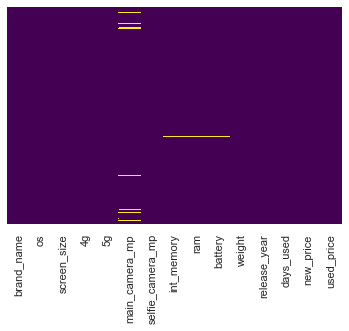

```python
# Above method doesn't show for all data, this chart might help
sns.heatmap(mobData.isnull(),yticklabels=False,cbar=False,cmap='viridis')
```

```python
np.random.seed(1)
mobData.sample(n=10) # Sample Data
```

|  | brand_name | os | screen_size | 4g | 5g | main_camera_mp | selfie_camera_mp | int_memory | ram | battery | weight | release_year | days_used | new_price | used_price |
| --- | --- | --- | --- | --- | --- | --- | --- | --- | --- | --- | --- | --- | --- | --- | --- |
| 2501 | Samsung | Android | 13.49 | yes | no | 13.00 | 13.00 | 32.00 | 4.00 | 3600.00 | 181.00 | 2017 | 683 | 198.68 | 79.47 |
| 2782 | Sony | Android | 13.81 | yes | no | NaN | 8.00 | 32.00 | 4.00 | 3300.00 | 156.00 | 2019 | 195 | 198.15 | 149.10 |
| 605 | Others | Android | 12.70 | yes | no | 8.00 | 5.00 | 16.00 | 4.00 | 2400.00 | 137.00 | 2015 | 1048 | 161.47 | 48.39 |
| 2923 | Vivo | Android | 19.37 | yes | no | 13.00 | 16.00 | 64.00 | 4.00 | 3260.00 | 149.30 | 2019 | 375 | 211.88 | 138.31 |
| 941 | Others | Others | 5.72 | no | no | 0.30 | 0.30 | 32.00 | 0.25 | 820.00 | 90.00 | 2013 | 883 | 29.81 | 8.92 |
| 1833 | LG | Android | 13.49 | no | no | 8.00 | 1.30 | 32.00 | 4.00 | 3140.00 | 161.00 | 2013 | 670 | 240.54 | 96.18 |
| 671 | Apple | iOS | 14.92 | yes | no | 12.00 | 7.00 | 64.00 | 4.00 | 5493.00 | 48.00 | 2018 | 403 | 700.15 | 350.08 |
| 1796 | LG | Android | 17.78 | yes | no | 5.00 | 0.30 | 16.00 | 4.00 | 4000.00 | 294.80 | 2014 | 708 | 189.30 | 75.94 |
| 757 | Asus | Android | 13.49 | yes | no | 13.00 | 8.00 | 32.00 | 4.00 | 5000.00 | 181.00 | 2017 | 612 | 270.50 | 108.13 |
| 3528 | Realme | Android | 15.72 | yes | no | NaN | 16.00 | 64.00 | 4.00 | 4035.00 | 184.00 | 2019 | 433 | 159.88 | 80.00 |

```python
# duplicate values check
mobData.duplicated().sum()
```

```
0
```

```python
# count of all variavle data types
mobData.dtypes.value_counts()
```

```
float64    9
object     4
int64      2
dtype: int64
```

```python
# check for number of unique values in the variables
mobData.nunique()
```

```
brand_name            34
os                     4
screen_size          127
4g                     2
5g                     2
main_camera_mp        44
selfie_camera_mp      37
int_memory            16
ram                   14
battery              354
weight               613
release_year           8
days_used            930
new_price           3099
used_price          3044
dtype: int64
```

```python
mobData = mobData.rename({"4g":"fourG","5g":"fiveG"}, axis='columns')
mobData.head()
```

|  | brand_name | os | screen_size | fourG | fiveG | main_camera_mp | selfie_camera_mp | int_memory | ram | battery | weight | release_year | days_used | new_price | used_price |
| --- | --- | --- | --- | --- | --- | --- | --- | --- | --- | --- | --- | --- | --- | --- | --- |
| 0 | Honor | Android | 23.97 | yes | no | 13.00 | 5.00 | 64.00 | 3.00 | 3020.00 | 146.00 | 2020 | 127 | 111.62 | 86.96 |
| 1 | Honor | Android | 28.10 | yes | yes | 13.00 | 16.00 | 128.00 | 8.00 | 4300.00 | 213.00 | 2020 | 325 | 249.39 | 161.49 |
| 2 | Honor | Android | 24.29 | yes | yes | 13.00 | 8.00 | 128.00 | 8.00 | 4200.00 | 213.00 | 2020 | 162 | 359.47 | 268.55 |
| 3 | Honor | Android | 26.04 | yes | yes | 13.00 | 8.00 | 64.00 | 6.00 | 7250.00 | 480.00 | 2020 | 345 | 278.93 | 180.23 |
| 4 | Honor | Android | 15.72 | yes | no | 13.00 | 8.00 | 64.00 | 3.00 | 5000.00 | 185.00 | 2020 | 293 | 140.87 | 103.80 |

```python
# Convert Categorical values
mobData['fourG'] = mobData.fourG.astype('category')
mobData['fiveG'] = mobData.fiveG.astype('category')
mobData['brand_name'] = mobData.brand_name.astype('category')
mobData['os'] = mobData.os.astype('category')
```

## Exploratory Data Analysis (EDA)

- EDA is an important part of any project involving data.
- It is important to investigate and understand the data better before building a model with it.
- A few questions have been mentioned below which will help you approach the analysis in the right manner and generate insights from the data.
- A thorough analysis of the data, in addition to the questions mentioned below, should be done.

```python
mobData.describe(exclude='number')# TO check for non-numerical attributes
```

|  | brand_name | os | fourG | fiveG |
| --- | --- | --- | --- | --- |
| count | 3571 | 3571 | 3571 | 3571 |
| unique | 34 | 4 | 2 | 2 |
| top | Others | Android | yes | no |
| freq | 509 | 3246 | 2359 | 3419 |

```python
# Let's look at the statistical summary of the data
pd.set_option(
    "display.float_format", lambda x: "%.2f" % x
)  # to display numbers rounded off to 2 decimal places

mobData.describe(include='all').T
```

|  | count | unique | top | freq | mean | std | min | 25% | 50% | 75% | max |
| --- | --- | --- | --- | --- | --- | --- | --- | --- | --- | --- | --- |
| brand_name | 3571 | 34 | Others | 509 | NaN | NaN | NaN | NaN | NaN | NaN | NaN |
| os | 3571 | 4 | Android | 3246 | NaN | NaN | NaN | NaN | NaN | NaN | NaN |
| screen_size | 3571.00 | NaN | NaN | NaN | 14.80 | 5.15 | 2.70 | 12.70 | 13.49 | 16.51 | 46.36 |
| fourG | 3571 | 2 | yes | 2359 | NaN | NaN | NaN | NaN | NaN | NaN | NaN |
| fiveG | 3571 | 2 | no | 3419 | NaN | NaN | NaN | NaN | NaN | NaN | NaN |
| main_camera_mp | 3391.00 | NaN | NaN | NaN | 9.40 | 4.82 | 0.08 | 5.00 | 8.00 | 13.00 | 48.00 |
| selfie_camera_mp | 3569.00 | NaN | NaN | NaN | 6.55 | 6.88 | 0.30 | 2.00 | 5.00 | 8.00 | 32.00 |
| int_memory | 3561.00 | NaN | NaN | NaN | 54.53 | 84.70 | 0.01 | 16.00 | 32.00 | 64.00 | 1024.00 |
| ram | 3561.00 | NaN | NaN | NaN | 4.06 | 1.39 | 0.03 | 4.00 | 4.00 | 4.00 | 16.00 |
| battery | 3565.00 | NaN | NaN | NaN | 3067.23 | 1364.21 | 80.00 | 2100.00 | 3000.00 | 4000.00 | 12000.00 |
| weight | 3564.00 | NaN | NaN | NaN | 179.42 | 90.28 | 23.00 | 140.00 | 159.00 | 184.00 | 950.00 |
| release_year | 3571.00 | NaN | NaN | NaN | 2015.96 | 2.29 | 2013.00 | 2014.00 | 2016.00 | 2018.00 | 2020.00 |
| days_used | 3571.00 | NaN | NaN | NaN | 675.39 | 248.64 | 91.00 | 536.00 | 690.00 | 872.00 | 1094.00 |
| new_price | 3571.00 | NaN | NaN | NaN | 237.39 | 197.55 | 9.13 | 120.13 | 189.80 | 291.94 | 2560.20 |
| used_price | 3571.00 | NaN | NaN | NaN | 109.88 | 121.50 | 2.51 | 45.20 | 75.53 | 126.00 | 1916.54 |

**Questions**:

1. What does the distribution of used phone prices look like?
2. What percentage of the used phone market is dominated by Android devices?
3. The amount of RAM is important for the smooth functioning of a phone. How does the amount of RAM vary with the brand?
4. A large battery often increases a phone's weight, making it feel uncomfortable in the hands. How does the weight vary for phones offering large batteries (more than 4500 mAh)?
5. Bigger screens are desirable for entertainment purposes as they offer a better viewing experience. How many phones are available across different brands with a screen size larger than 6 inches?
6. Budget phones nowadays offer great selfie cameras, allowing us to capture our favorite moments with loved ones. What is the distribution of budget phones offering greater than 8MP selfie cameras across brands?
7. Which attributes are highly correlated with the used phone price?

```python
# While doing uni-variate analysis of numerical variables we want to study their central tendency
# and dispersion.
# Let us write a function that will help us create boxplot and histogram for any input numerical
# variable.
# This function takes the numerical column as the input and returns the boxplots
# and histograms for the variable.
# Let us see if this help us write faster and cleaner code.
# function to plot a boxplot and a histogram along the same scale.


def histogram_boxplot(data, feature, figsize=(12, 7), kde=False, bins=None):
    """
    Boxplot and histogram combined

    data: dataframe
    feature: dataframe column
    figsize: size of figure (default (12,7))
    kde: whether to show the density curve (default False)
    bins: number of bins for histogram (default None)
    """
    f2, (ax_box2, ax_hist2) = plt.subplots(
        nrows=2,  # Number of rows of the subplot grid= 2
        sharex=True,  # x-axis will be shared among all subplots
        gridspec_kw={"height_ratios": (0.25, 0.75)},
        figsize=figsize,
    )  # creating the 2 subplots
    sns.boxplot(
        data=data, x=feature, ax=ax_box2, showmeans=True, color="violet"
    )  # boxplot will be created and a star will indicate the mean value of the column
    sns.histplot(
        data=data, x=feature, kde=kde, ax=ax_hist2, bins=bins, palette="winter"
    ) if bins else sns.histplot(
        data=data, x=feature, kde=kde, ax=ax_hist2
    )  # For histogram
    ax_hist2.axvline(
        data[feature].mean(), color="green", linestyle="--"
    )  # Add mean to the histogram
    ax_hist2.axvline(
        data[feature].median(), color="black", linestyle="-"
    )  # Add median to the histogram
```

```python
mobData.used_price.describe(include='all')
```

```
count   3571.00
mean     109.88
std      121.50
min        2.51
25%       45.20
50%       75.53
75%      126.00
max     1916.54
Name: used_price, dtype: float64
```

### Q1.Distribution of Used phone prices

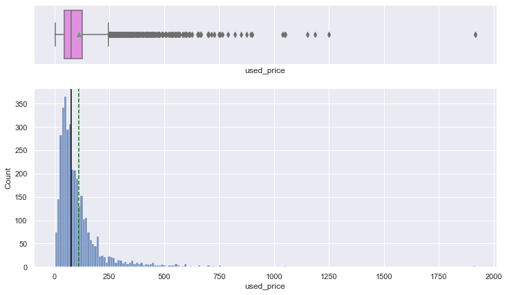

```python
#Used Price analysis
histogram_boxplot(mobData, "used_price")
```

- Distribution is heavily right skewed
- Outliers present mostly towards right
- Mean is very much greater than Median
- Most values (50%) are between 45 and 126

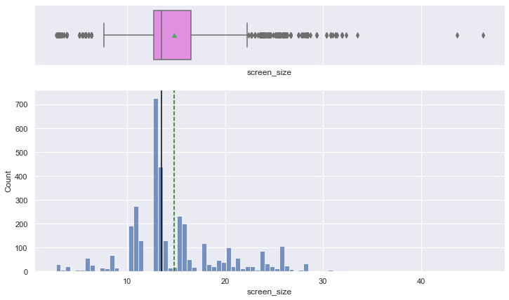

```python
#screen size analysis
histogram_boxplot(mobData, "screen_size")
```

- Right skewed distribution again
- lot of outliers on low and high end

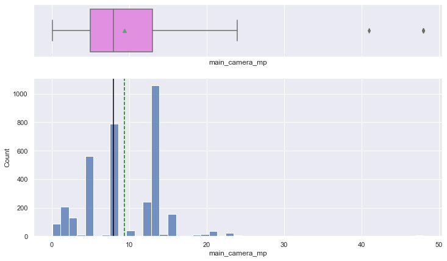

```python
#main camera analysis
histogram_boxplot(mobData, "main_camera_mp")
```

- Less outliers
- bit of right skewed

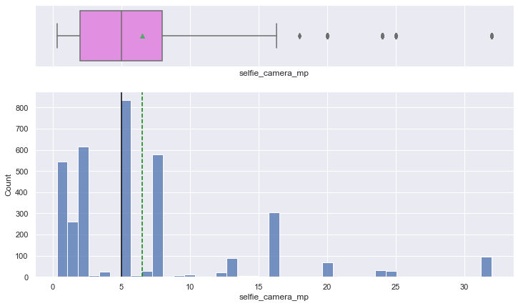

```python
#selfie camera analysis
histogram_boxplot(mobData, "selfie_camera_mp")
```

- Again right skwewed with outliers towards higher value
- Missing values

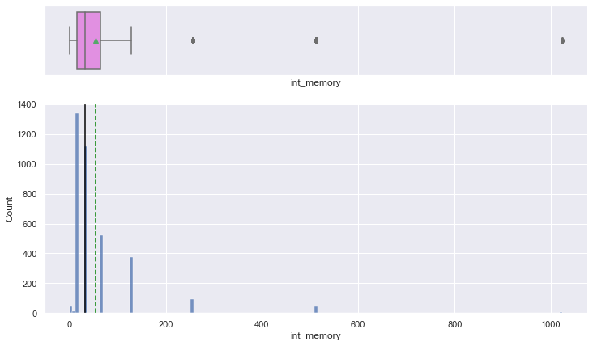

```python
#Internal memory analysis
histogram_boxplot(mobData, "int_memory")
```

- Again very much right skewed with few outliers
- Few missing values

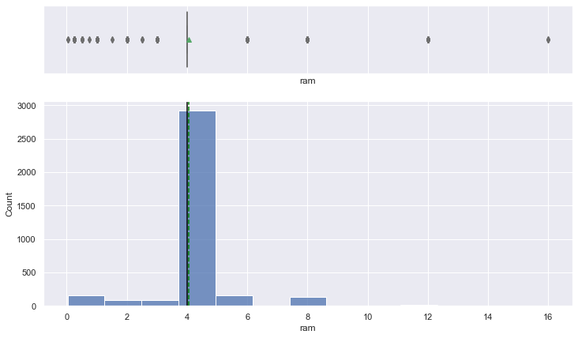

```python
#RAM analysis
histogram_boxplot(mobData, "ram")
```

- outliers at low and higher ends
- Has missing values
- Unimodal distribution

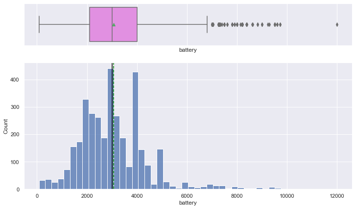

```python
#Battery analysis
histogram_boxplot(mobData, "battery")
```

- Right skewed distribution
- Few missing values
- Outliers on higher end

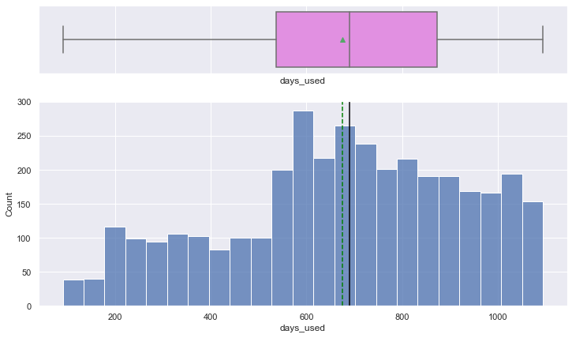

```python
#Battery analysis
histogram_boxplot(mobData, "days_used")
```

```python
# function to create labeled barplots


def labeled_barplot(data, feature, perc=False, n=None):
    """
    Barplot with percentage at the top

    data: dataframe
    feature: dataframe column
    perc: whether to display percentages instead of count (default is False)
    n: displays the top n category levels (default is None, i.e., display all levels)
    """

    total = len(data[feature])  # length of the column
    count = data[feature].nunique()
    if n is None:
        plt.figure(figsize=(count + 1, 5))
    else:
        plt.figure(figsize=(n + 1, 5))

    plt.xticks(rotation=90, fontsize=15)
    ax = sns.countplot(
        data=data,
        x=feature,
        palette="Paired",
        order=data[feature].value_counts().index[:n].sort_values(),
    )

    for p in ax.patches:
        if perc == True:
            label = "{:.1f}%".format(
                100 * p.get_height() / total
            )  # percentage of each class of the category
        else:
            label = p.get_height()  # count of each level of the category

        x = p.get_x() + p.get_width() / 2  # width of the plot
        y = p.get_height()  # height of the plot

        ax.annotate(
            label,
            (x, y),
            ha="center",
            va="center",
            size=12,
            xytext=(0, 5),
            textcoords="offset points",
        )  # annotate the percentage

    plt.show()  # show the plot
```

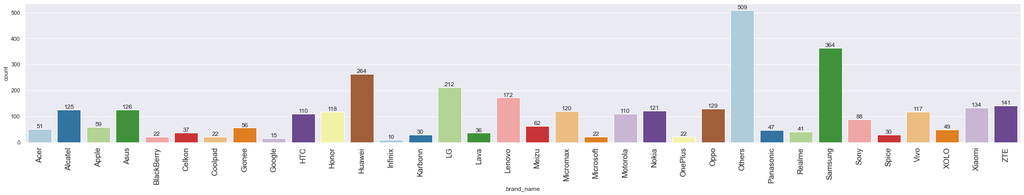

```python
# CAtegorical Brand Name distribution
labeled_barplot(mobData, "brand_name")
```

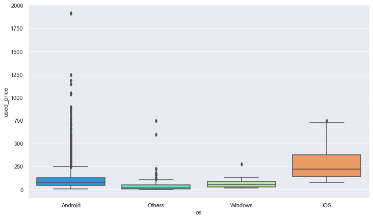

```python
#Brand vs Used_price
plt.figure(figsize=(12,7))
sns.boxplot(x='os',y='used_price',data=mobData,palette='rainbow')
plt.show()
```

```python
# Average price by brand
brandData = mobData.groupby('brand_name')['used_price'].mean();
brandData
```

```
brand_name
Acer          63.80
Alcatel       55.33
Apple        293.23
Asus         103.76
BlackBerry   102.04
Celkon        22.65
Coolpad       77.93
Gionee        91.88
Google       239.21
HTC           99.63
Honor        132.29
Huawei       176.26
Infinix       68.98
Karbonn       38.07
LG           115.85
Lava          40.11
Lenovo        77.15
Meizu        126.52
Micromax      38.13
Microsoft     55.32
Motorola     107.70
Nokia         59.39
OnePlus      318.52
Oppo         180.85
Others        78.49
Panasonic     60.30
Realme       124.17
Samsung      132.08
Sony         119.89
Spice         32.30
Vivo         168.19
XOLO          47.34
Xiaomi       137.47
ZTE           93.62
Name: used_price, dtype: float64
```